# F9_07_COMP_KONTR_ADDR_CITY

Independent contractor city · Code report

## Overview

**Description**

**Table**

`F9-P07-T02-CONTRACTORS` (many)

**Location code**

`F990-PC-PART-07-SECTION-B-LINE-01-COL-A`, `F990-EZ-PART-06-LINE-51-COL-A`

**Family**

`F990-PC-PART-07-SECTION-B-LINE-01-COL-A` · siblings: F9_07_COMP_KONTR_ADDR_CNTR, F9_07_COMP_KONTR_ADDR_L1, F9_07_COMP_KONTR_ADDR_L2, F9_07_COMP_KONTR_ADDR_STATE, F9_07_COMP_KONTR_ADDR_ZIP, F9_07_COMP_KONTR_NAME_ORG_L1

**Data type**

text (xsd: TextType, CityType, , CountryType)

**Scope**

PZ

**Status**

unreviewed

14

xpaths mapped (11 observed)

502,969

filings with a value

2009–2024

tax years observed

9

open flags (1 errors)

## Flags

| Severity | Flag | Xpath | Detail |
| --- | --- | --- | --- |
| ⚠ error | `COLLISION` | IRS990/ContractorCompensationGrp/ContractorAddress/ForeignAddress/CityNm | 9061 filings contain 2+ of its xpaths; most common set: /Return/ReturnData/IRS990/ContractorCompensationGrp/ContractorAddress/ForeignAddress/CityNm ; /Return/ReturnData/IRS990/ContractorCompensationGr… |
| ⓘ info | `MANY_NOT_REPEATING` | IRS990EZ/CompensationOfHghstPdCntrctGrp/USAddress/CityNm | many-to-one table, but 84% of values sit in no repeating element |
| ⓘ info | `MANY_NOT_REPEATING` | IRS990EZ/CompOfHghstPaidCntrctProfSer/AddressUS/City | many-to-one table, but 86% of values sit in no repeating element |
| ⓘ info | `MANY_NOT_REPEATING` | IRS990EZ/CompensationOfHghstPdCntrctGrp/USAddress/City | many-to-one table, but 88% of values sit in no repeating element |
| ⓘ info | `MANY_NOT_REPEATING` | IRS990EZ/CompensationOfHghstPdCntrctGrp/ForeignAddress/CityNm | many-to-one table, but 85% of values sit in no repeating element |
| ⓘ info | `MANY_NOT_REPEATING` | IRS990EZ/CompOfHghstPaidCntrctProfSer/AddressForeign/City | many-to-one table, but 100% of values sit in no repeating element |
| ⓘ info | `UNOBSERVED` | IRS990/Form990PartVIISectionB/ContractorCompensation/AddressOfContractor/AddressForeign/City | never observed in TY2009-2024 filings |
| ⓘ info | `UNOBSERVED` | IRS990/Form990PartVIISectionB/ContractorCompensation/AddressOfContractor/AddressUS/City | never observed in TY2009-2024 filings |
| ⓘ info | `UNOBSERVED` | IRS990EZ/CompensationOfHghstPdCntrctGrp/ForeignAddress/City | never observed in TY2009-2024 filings |

## Xpaths

All mapped xpaths (under /Return/ReturnData or /Return/ReturnHeader), oldest first. Charts label each series by its xpath.

| Xpath | Form | Chart label | First year | Last year | Versions | Filings | Repeats in |
| --- | --- | --- | --- | --- | --- | --- | --- |
| IRS990/ContractorCompensation/AddressOfContractor/AddressUS/City | 990 | …ContractorCompensation/AddressOfContractor/AddressUS/City | 2009 | 2012 | 18 | 77,556 | 65.2% |
| IRS990/ContractorCompensation/AddressOfContractor/AddressForeign/City | 990 | …actorCompensation/AddressOfContractor/AddressForeign/City | 2009 | 2012 | 16 | 1,543 | 31.7% |
| IRS990EZ/CompOfHghstPaidCntrctProfSer/AddressUS/City | 990-EZ | same | 2009 | 2012 | 14 | 361 | 14.4% |
| IRS990EZ/CompOfHghstPaidCntrctProfSer/AddressForeign/City | 990-EZ | same | 2011 | 2011 | 1 | 2 | 0.0% |
| IRS990/ContractorCompensationGrp/ContractorAddress/USAddress/City | 990 | …ontractorCompensationGrp/ContractorAddress/USAddress/City | 2013 | 2013 | 3 | 26,338 | 62.8% |
| IRS990/ContractorCompensationGrp/ContractorAddress/ForeignAddress/City | 990 | …ctorCompensationGrp/ContractorAddress/ForeignAddress/City | 2013 | 2013 | 3 | 571 | 33.5% |
| IRS990EZ/CompensationOfHghstPdCntrctGrp/USAddress/City | 990-EZ | same | 2013 | 2013 | 3 | 113 | 12.4% |
| IRS990/ContractorCompensationGrp/ContractorAddress/ForeignAddress/CityNm | 990 | Other | 2014 | 2024 | 33 | 10,752 | 36.1% |
| IRS990/ContractorCompensationGrp/ContractorAddress/USAddress/CityNm | 990 | Other | 2014 | 2024 | 34 | 383,412 | 62.9% |
| IRS990/Form990PartVIISectionB/ContractorCompensation/AddressOfContractor/AddressForeign/City | 990 | Other |  |  |  | 0 |  |
| IRS990/Form990PartVIISectionB/ContractorCompensation/AddressOfContractor/AddressUS/City | 990 | Other |  |  |  | 0 |  |
| IRS990EZ/CompensationOfHghstPdCntrctGrp/ForeignAddress/City | 990-EZ | Other |  |  |  | 0 |  |
| IRS990EZ/CompensationOfHghstPdCntrctGrp/ForeignAddress/CityNm | 990-EZ | Other | 2015 | 2024 | 18 | 55 | 12.7% |
| IRS990EZ/CompensationOfHghstPdCntrctGrp/USAddress/CityNm | 990-EZ | Other | 2014 | 2024 | 34 | 2,266 | 16.3% |

## Coverage

[figure not shown]

**Table view**

Table view: filings by tax year and series

| Tax year | …ContractorCompensation/AddressOfContractor/AddressUS/City | …actorCompensation/AddressOfContractor/AddressForeign/City | IRS990EZ/CompOfHghstPaidCntrctProfSer/AddressUS/City | IRS990EZ/CompOfHghstPaidCntrctProfSer/AddressForeign/City | …ontractorCompensationGrp/ContractorAddress/USAddress/City | …ctorCompensationGrp/ContractorAddress/ForeignAddress/City | IRS990EZ/CompensationOfHghstPdCntrctGrp/USAddress/City | Other |
| --- | --- | --- | --- | --- | --- | --- | --- | --- |
| 2009 | 9,378 | 192 | 55 | 0 | 0 | 0 | 0 | 0 |
| 2010 | 20,146 | 404 | 84 | 0 | 0 | 0 | 0 | 0 |
| 2011 | 23,209 | 445 | 104 | 2 | 0 | 0 | 0 | 0 |
| 2012 | 24,823 | 502 | 118 | 0 | 0 | 0 | 0 | 0 |
| 2013 | 0 | 0 | 0 | 0 | 26,338 | 571 | 113 | 0 |
| 2014 | 0 | 0 | 0 | 0 | 0 | 0 | 0 | 29,000 |
| 2015 | 0 | 0 | 0 | 0 | 0 | 0 | 0 | 30,771 |
| 2016 | 0 | 0 | 0 | 0 | 0 | 0 | 0 | 32,061 |
| 2017 | 0 | 0 | 0 | 0 | 0 | 0 | 0 | 34,937 |
| 2018 | 0 | 0 | 0 | 0 | 0 | 0 | 0 | 35,402 |
| 2019 | 0 | 0 | 0 | 0 | 0 | 0 | 0 | 36,619 |
| 2020 | 0 | 0 | 0 | 0 | 0 | 0 | 0 | 38,335 |
| 2021 | 0 | 0 | 0 | 0 | 0 | 0 | 0 | 40,291 |
| 2022 | 0 | 0 | 0 | 0 | 0 | 0 | 0 | 43,164 |
| 2023 | 0 | 0 | 0 | 0 | 0 | 0 | 0 | 45,096 |
| 2024 | 0 | 0 | 0 | 0 | 0 | 0 | 0 | 30,809 |

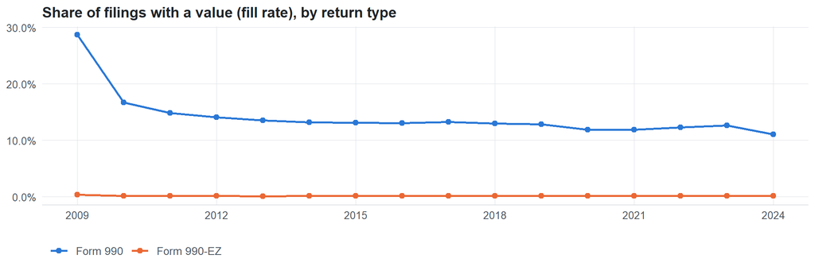

**Table view**

Table view: fill rate

| Tax year | Return type | Filings | All filings | Fill rate |
| --- | --- | --- | --- | --- |
| 2009 | Form 990 | 9,570 | 33,311 | 28.73% |
| 2009 | Form 990-EZ | 55 | 15,470 | 0.36% |
| 2010 | Form 990 | 20,550 | 123,025 | 16.70% |
| 2010 | Form 990-EZ | 84 | 63,326 | 0.13% |
| 2011 | Form 990 | 23,654 | 159,504 | 14.83% |
| 2011 | Form 990-EZ | 106 | 82,048 | 0.13% |
| 2012 | Form 990 | 25,325 | 179,688 | 14.09% |
| 2012 | Form 990-EZ | 118 | 93,750 | 0.13% |
| 2013 | Form 990 | 26,909 | 198,855 | 13.53% |
| 2013 | Form 990-EZ | 113 | 104,375 | 0.11% |
| 2014 | Form 990 | 28,871 | 218,619 | 13.21% |
| 2014 | Form 990-EZ | 129 | 116,417 | 0.11% |
| 2015 | Form 990 | 30,626 | 233,519 | 13.11% |
| 2015 | Form 990-EZ | 145 | 124,894 | 0.12% |
| 2016 | Form 990 | 31,894 | 243,903 | 13.08% |
| 2016 | Form 990-EZ | 167 | 130,484 | 0.13% |
| 2017 | Form 990 | 34,770 | 261,612 | 13.29% |
| 2017 | Form 990-EZ | 167 | 139,144 | 0.12% |
| 2018 | Form 990 | 35,229 | 271,442 | 12.98% |
| 2018 | Form 990-EZ | 173 | 149,384 | 0.12% |
| 2019 | Form 990 | 36,415 | 283,694 | 12.84% |
| 2019 | Form 990-EZ | 204 | 152,622 | 0.13% |
| 2020 | Form 990 | 38,108 | 320,342 | 11.90% |
| 2020 | Form 990-EZ | 227 | 169,864 | 0.13% |
| 2021 | Form 990 | 40,018 | 336,480 | 11.89% |
| 2021 | Form 990-EZ | 271 | 202,724 | 0.13% |
| 2022 | Form 990 | 42,861 | 349,055 | 12.28% |
| 2022 | Form 990-EZ | 303 | 206,130 | 0.15% |
| 2023 | Form 990 | 44,811 | 354,768 | 12.63% |
| 2023 | Form 990-EZ | 285 | 206,379 | 0.14% |
| 2024 | Form 990 | 30,559 | 277,298 | 11.02% |
| 2024 | Form 990-EZ | 250 | 178,867 | 0.14% |

## Repeating groups

Table cardinality in the concordance: **many**. 10 of 11 observed xpaths repeat within a filing.

Repeating element each xpath was observed in (from the raw indexed xpath)

| Xpath | Repeating element | Filings (summed over years) |
| --- | --- | --- |
| IRS990/ContractorCompensation/AddressOfContractor/AddressForeign/City | (none) | 239 |
| IRS990/ContractorCompensation/AddressOfContractor/AddressForeign/City | IRS990/ContractorCompensation | 1304 |
| IRS990/ContractorCompensation/AddressOfContractor/AddressUS/City | (none) | 26671 |
| IRS990/ContractorCompensation/AddressOfContractor/AddressUS/City | IRS990/ContractorCompensation | 50885 |
| IRS990EZ/CompOfHghstPaidCntrctProfSer/AddressUS/City | (none) | 309 |
| IRS990EZ/CompOfHghstPaidCntrctProfSer/AddressUS/City | IRS990EZ/CompOfHghstPaidCntrctProfSer | 52 |
| IRS990EZ/CompOfHghstPaidCntrctProfSer/AddressForeign/City | (none) | 2 |
| IRS990/ContractorCompensationGrp/ContractorAddress/ForeignAddress/City | (none) | 85 |
| IRS990/ContractorCompensationGrp/ContractorAddress/ForeignAddress/City | IRS990/ContractorCompensationGrp | 486 |
| IRS990/ContractorCompensationGrp/ContractorAddress/USAddress/City | (none) | 9683 |
| IRS990/ContractorCompensationGrp/ContractorAddress/USAddress/City | IRS990/ContractorCompensationGrp | 16655 |
| IRS990EZ/CompensationOfHghstPdCntrctGrp/USAddress/City | (none) | 99 |
| IRS990EZ/CompensationOfHghstPdCntrctGrp/USAddress/City | IRS990EZ/CompensationOfHghstPdCntrctGrp | 14 |
| IRS990/ContractorCompensationGrp/ContractorAddress/ForeignAddress/CityNm | (none) | 1726 |
| IRS990/ContractorCompensationGrp/ContractorAddress/ForeignAddress/CityNm | IRS990/ContractorCompensationGrp | 9026 |
| IRS990/ContractorCompensationGrp/ContractorAddress/USAddress/CityNm | (none) | 140318 |
| IRS990/ContractorCompensationGrp/ContractorAddress/USAddress/CityNm | IRS990/ContractorCompensationGrp | 243094 |
| IRS990EZ/CompensationOfHghstPdCntrctGrp/USAddress/CityNm | (none) | 1894 |
| IRS990EZ/CompensationOfHghstPdCntrctGrp/USAddress/CityNm | IRS990EZ/CompensationOfHghstPdCntrctGrp | 372 |
| IRS990EZ/CompensationOfHghstPdCntrctGrp/ForeignAddress/CityNm | (none) | 47 |
| IRS990EZ/CompensationOfHghstPdCntrctGrp/ForeignAddress/CityNm | IRS990EZ/CompensationOfHghstPdCntrctGrp | 8 |

## Values

| Result | Check | Detail |
| --- | --- | --- |
| ▲ warn | Small code list | up to 10306 distinct values per xpath and year |
| ▲ warn | Codes share one format | 27% have the shape AAAAAAA |
| ✓ pass | Consistent letter case | 0.0% of values are lower case |

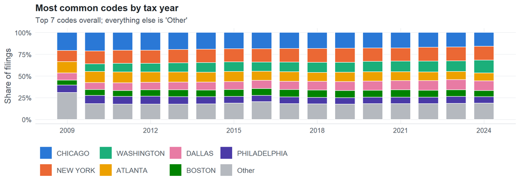

**Table view**

Table view: filings by code and tax year

| tax_year | CHICAGO | NEW YORK | WASHINGTON | ATLANTA | DALLAS | BOSTON | PHILADELPHIA | Other |
| --- | --- | --- | --- | --- | --- | --- | --- | --- |
| 2009 | 741 | 466 | 0 | 471 | 292 | 208 | 305 | 1,117 |
| 2010 | 1,857 | 1,280 | 779 | 1,117 | 698 | 588 | 821 | 1,574 |
| 2011 | 2,037 | 1,484 | 995 | 1,243 | 861 | 669 | 898 | 1,732 |
| 2012 | 2,177 | 1,621 | 1,053 | 1,294 | 914 | 779 | 968 | 1,888 |
| 2013 | 2,179 | 1,718 | 1,166 | 1,308 | 992 | 895 | 939 | 1,973 |
| 2014 | 2,290 | 1,839 | 1,321 | 1,358 | 1,082 | 947 | 956 | 2,148 |
| 2015 | 2,298 | 1,851 | 1,349 | 1,426 | 1,145 | 966 | 940 | 2,293 |
| 2016 | 2,299 | 1,858 | 1,274 | 1,303 | 1,144 | 975 | 881 | 2,481 |
| 2017 | 2,727 | 2,339 | 1,638 | 1,642 | 1,408 | 1,237 | 1,132 | 2,707 |
| 2018 | 2,769 | 2,416 | 1,759 | 1,576 | 1,511 | 1,285 | 1,126 | 2,695 |
| 2019 | 2,822 | 2,527 | 1,802 | 1,674 | 1,578 | 1,287 | 1,159 | 2,762 |
| 2020 | 2,853 | 2,436 | 1,956 | 1,717 | 1,659 | 1,308 | 1,164 | 2,904 |
| 2021 | 2,999 | 2,589 | 2,053 | 1,712 | 1,807 | 1,434 | 1,261 | 3,067 |
| 2022 | 3,152 | 2,973 | 2,281 | 1,858 | 2,076 | 1,484 | 1,364 | 3,365 |
| 2023 | 3,136 | 3,042 | 2,317 | 1,760 | 2,173 | 1,490 | 1,484 | 3,492 |
| 2024 | 1,916 | 1,950 | 1,773 | 1,092 | 1,344 | 871 | 891 | 2,277 |

Code frequencies (all xpaths, all years)

| Code | Filings | Share |
| --- | --- | --- |
| CHICAGO | 38,252 | 18.3% |
| NEW YORK | 32,389 | 15.5% |
| WASHINGTON | 23,516 | 11.3% |
| ATLANTA | 22,551 | 10.8% |
| DALLAS | 20,684 | 9.9% |
| BOSTON | 16,423 | 7.9% |
| PHILADELPHIA | 16,289 | 7.8% |
| LOS ANGELES | 13,918 | 6.7% |
| PITTSBURGH | 10,102 | 4.8% |
| Chicago | 4,634 | 2.2% |
| SAN FRANCISCO | 3,306 | 1.6% |
| MINNEAPOLIS | 2,116 | 1.0% |
| LONDON | 1,137 | 0.5% |
| TORONTO | 668 | 0.3% |
| Atlanta | 254 | 0.1% |
| JERUSALEM | 251 | 0.1% |
| VANCOUVER | 228 | 0.1% |
| London | 226 | 0.1% |
| MONTREAL | 198 | 0.1% |
| New York | 192 | 0.1% |
| Toronto | 182 | 0.1% |
| PARIS | 110 | 0.1% |
| TEL AVIV | 102 | 0.0% |
| BRUSSELS | 98 | 0.0% |
| NAIROBI | 98 | 0.0% |
| DUBLIN | 74 | 0.0% |
| NONE | 69 | 0.0% |
|  | 46 | 0.0% |
| OTTAWA | 39 | 0.0% |
| Washington | 37 | 0.0% |

First rows shown.

## Examples

| Tax year | Return | Xpath | Organization | Value | Source |
| --- | --- | --- | --- | --- | --- |
| 2024 | 990 | IRS990/ContractorCompensationGrp/ContractorAddress/ForeignAddress/CityNm | Angel Christian Television Trust Inc | Plymouth | [XML](https://gt990datalake-rawdata.s3.amazonaws.com/EfileData/XmlFiles/202630279349300528_public.xml) |
| 2024 | 990 | IRS990/ContractorCompensationGrp/ContractorAddress/USAddress/CityNm | YMCA OF THE FOOTHILLS | LOS ANGELES | [XML](https://gt990datalake-rawdata.s3.amazonaws.com/EfileData/XmlFiles/202532059349301333_public.xml) |
| 2024 | 990EZ | IRS990EZ/CompensationOfHghstPdCntrctGrp/ForeignAddress/CityNm | Public Node | Chelmsford | [XML](https://gt990datalake-rawdata.s3.amazonaws.com/EfileData/XmlFiles/202541259349202659_public.xml) |
| 2024 | 990EZ | IRS990EZ/CompensationOfHghstPdCntrctGrp/USAddress/CityNm | BLACK FILMMAKER FOUNDATION INC | NEW YORK | [XML](https://gt990datalake-rawdata.s3.amazonaws.com/EfileData/XmlFiles/202511609349200126_public.xml) |
| 2023 | 990 | IRS990/ContractorCompensationGrp/ContractorAddress/ForeignAddress/CityNm | AACN CERTIFICATION CORP | Pickering | [XML](https://gt990datalake-rawdata.s3.amazonaws.com/EfileData/XmlFiles/202521329349306552_public.xml) |
| 2023 | 990 | IRS990/ContractorCompensationGrp/ContractorAddress/USAddress/CityNm | Changing Tides Family Services | Eureka | [XML](https://gt990datalake-rawdata.s3.amazonaws.com/EfileData/XmlFiles/202530989349300133_public.xml) |
| 2023 | 990EZ | IRS990EZ/CompensationOfHghstPdCntrctGrp/ForeignAddress/CityNm | GLOBAL MIRACLE MINISTRY INC | COBBETT H ILL ROAD | [XML](https://gt990datalake-rawdata.s3.amazonaws.com/EfileData/XmlFiles/202413119349201796_public.xml) |
| 2023 | 990EZ | IRS990EZ/CompensationOfHghstPdCntrctGrp/USAddress/CityNm | LOS ANGELES SYMPHONIC WINDS | MOORPARK | [XML](https://gt990datalake-rawdata.s3.amazonaws.com/EfileData/XmlFiles/202423519349201352_public.xml) |
| 2022 | 990 | IRS990/ContractorCompensationGrp/ContractorAddress/ForeignAddress/CityNm | CODEORG | MADRID | [XML](https://gt990datalake-rawdata.s3.amazonaws.com/EfileData/XmlFiles/202313199349312426_public.xml) |
| 2022 | 990 | IRS990/ContractorCompensationGrp/ContractorAddress/USAddress/CityNm | NATIONAL CONSTITUTION CENTER | PHILADELPHIA | [XML](https://gt990datalake-rawdata.s3.amazonaws.com/EfileData/XmlFiles/202420509349300732_public.xml) |
| 2022 | 990EZ | IRS990EZ/CompensationOfHghstPdCntrctGrp/ForeignAddress/CityNm | Hungarian Ministries International | Akademia | [XML](https://gt990datalake-rawdata.s3.amazonaws.com/EfileData/XmlFiles/202303089349200705_public.xml) |
| 2022 | 990EZ | IRS990EZ/CompensationOfHghstPdCntrctGrp/USAddress/CityNm | DOGS FOR LAW ENFORCEMENT | Houston | [XML](https://gt990datalake-rawdata.s3.amazonaws.com/EfileData/XmlFiles/202422289349201037_public.xml) |

## Reviewer checklist

- The definition matches the form line and instructions for every xpath’s schema years.
- Every xpath pooled here measures the same thing on the 990 and 990-EZ (close enough for analysis).
- The coverage chart has no unexplained gaps or jumps between tax years.
- Each open flag is fixed, or accepted with a note in validation_log.csv.
- Every code is valid for the list the form uses (state, country, valuation method, …).
- The code list and its meaning did not change across schema versions.
- Codes are stored as text, so values like leading zeros are preserved.

Record the review as a row in `inst/extdata/src/validation_log.csv` (variable_name, reviewer, date, status, note). Evidence built 2026-09-23 17:09:04 MST from the ef2 DuckDB builds (tax years 2009–2024).